# Human Activity Recognition Assignment

Andrew Januszewski

March 17, 2019

## Executive Summary

In this project, you will use data from accelerometers on the belt, forearm, arm, and dumbell of 6 participants. They were asked to perform Unilateral Dumbbell Biceps Curls correctly and incorrectly in 5 different ways. Your goal is to predict the manner in which they did the exercise:

- Exactly according to the specification (Class A)
- Throwing the elbows to the front (Class B)
- Lifting the dumbbell only halfway (Class C)
- Lowering the dumbbell only halfway (Class D)
- Throwing the hips to the front (Class E)

More information is available from the website here: http://web.archive.org/web/20161224072740/http:/groupware.les.inf.puc-rio.br/har

## Setup

```r
library(tidyverse)
library(GGally)
library(data.table)
library(caret)
library(e1071)
library(Boruta)
library(xgboost)

train_data <- fread('pml-training.csv')

test_data <- fread('pml-testing.csv')
```

## Exploratory Data Analysis

At first glance, it seems some columns are rarely populated.

```r
na_perc <-
  colMeans(is.na(train_data)) %>%
  as.data.frame() %>%
  rownames_to_column() %>%
  rename(field = 1, perc_na = 2) %>%
  arrange(desc(perc_na))
```

For verbosity concerns, I did not output the table in this document. However, there are 100 fields that are 98% or more NA. If the population rate were more reasonable, we could impute values and preserve these fields. Instead, we will need to exclude them going forward.

```r
low_na_perc_fields <-
  na_perc %>%
  filter(round(perc_na, 2) < 0.98) %>%
  as.list(field)

train_data_sub <-
  train_data %>%
  select(low_na_perc_fields$field)

preds <-
  low_na_perc_fields$field[8:59] # Item 60 is classe which doesn't exist in the test set

test_data_sub <-
  test_data %>%
  select(low_na_perc_fields$field[1:59]) # Item 60 is classe which doesn't exist in the test set
```

## Feature Selection

The amount of fields is somewhat more manageable now, but 52 remaining predictors is still alot to individually explore. The Boruta package can help us systematically perform feature selection. However, it can be very computationally expensive.

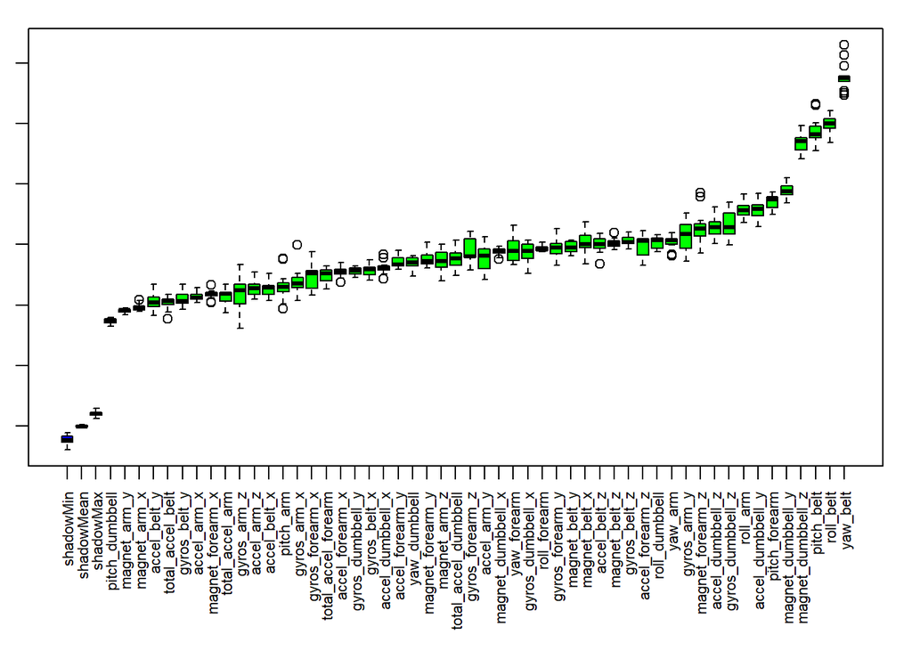

```r
preds_and_class <-
  c(preds, 'classe')

train_data_for_boruta <-
  train_data_sub[, ..preds_and_class] %>%
  transform(classe = as.factor(classe))

boruta_fs <-
  Boruta(data = train_data_for_boruta
         ,classe ~ .
         ,doTrace = 2)

par(mar = c(7, 1, 1, 1) + 0.1)
plot(boruta_fs, xlab = "", xaxt = "n")
lz <- lapply(1:ncol(boruta_fs$ImpHistory), function(i) boruta_fs$ImpHistory[is.finite(boruta_fs$ImpHistory[,i]),i])
names(lz) <- colnames(boruta_fs$ImpHistory)
Labels <- sort(sapply(lz,median))
axis(side = 1,las = 2, labels = names(Labels),
       at = 1:ncol(boruta_fs$ImpHistory), cex.axis = 0.7)
```

Surpisingly, Boruta found all fields statistically significant. There is a lot of correlation among the predictors though (output ommitted for size). For the purpose of this assignment, I won’t be attempting to surgically prune the predictors. I’ll simply remove any with strong correlation then move straight to modeling.

```r
cor_test <-
  cor(train_data_sub[, ..preds])

cor_preds <-
  findCorrelation(cor_test, cutoff = 0.7)

fin_preds <-
  preds_and_class[-cor_preds]
```

## Modeling

First, let’s create a validation set from the training data. Then we’ll train several classifiers on the remaining training data.

```r
val_index <-
  createDataPartition(y = train_data_sub$classe, p = 0.3, list = F)

validation_set <-
  train_data_sub[val_index, ..fin_preds] %>%
  transform(classe = as.factor(classe))

training_set <-
  train_data_sub[-val_index, ..fin_preds] %>%
  transform(classe = as.factor(classe))
```

The default sampling method in caret is boostrap so we need to change that as per the assignment’s instructions. In this case, I chose repeated cross-validation with 10 repeats and 5 folds.

```r
ctrl <-
  trainControl(method = 'repeatedcv'
               ,repeats = 10
               ,number = 5)
```

# Random Forest

```r
model_rf <-
  train(x = training_set[ , gyros_belt_x:magnet_forearm_z]
        ,y = training_set$classe
        ,method = 'rf'
        ,trControl = ctrl)

saveRDS(model_rf, 'model_rf.rds')

predict_rf <-
  predict(model_rf, validation_set)

confusionMatrix(validation_set$classe, predict_rf)
```

# Gradient Boosting Machine

```r
model_gbm <-
  train(x = training_set[ , gyros_belt_x:magnet_forearm_z]
        ,y = training_set$classe
        ,method = 'gbm'
        ,trControl = ctrl)

saveRDS(model_gbm, 'model_gbm.rds')

predict_gbm <-
  predict(model_gbm, validation_set)

confusionMatrix(validation_set$classe, predict_gbm)
```

[output not shown]

# XGB TREE

```r
model_xgbt <-
  train(x = training_set[ , gyros_belt_x:magnet_forearm_z]
        ,y = training_set$classe
        ,method = 'xgbTree'
        ,trControl = ctrl)

saveRDS(model_xgbt, 'model_xgbt.rds')

predict_xgbt <-
  predict(model_xgbt, validation_set)

confusionMatrix(validation_set$classe, predict_xgbt)
```

[output not shown]

## Summary

The model placed high importance on magnetometer readings on the dumbbell and belt, as well as forearm pitch and roll.

```r
model_rf <-
  readRDS('model_rf.rds')

predict_rf <-
  predict(model_rf, validation_set)

confusionMatrix(validation_set$classe, predict_rf)
```

```
## Confusion Matrix and Statistics
##
##           Reference
## Prediction    A    B    C    D    E
##          A 1673    1    0    0    0
##          B    8 1131    1    0    0
##          C    0    1 1023    3    0
##          D    0    0   10  955    0
##          E    0    0    0    0 1083
##
## Overall Statistics
##
##                Accuracy : 0.9959
##                  95% CI : (0.9939, 0.9974)
##     No Information Rate : 0.2854
##     P-Value [Acc > NIR] : < 2.2e-16
##
##                   Kappa : 0.9948
##  Mcnemar's Test P-Value : NA
##
## Statistics by Class:
##
##                      Class: A Class: B Class: C Class: D Class: E
## Sensitivity            0.9952   0.9982   0.9894   0.9969   1.0000
## Specificity            0.9998   0.9981   0.9992   0.9980   1.0000
## Pos Pred Value         0.9994   0.9921   0.9961   0.9896   1.0000
## Neg Pred Value         0.9981   0.9996   0.9977   0.9994   1.0000
## Prevalence             0.2854   0.1924   0.1756   0.1627   0.1839
## Detection Rate         0.2841   0.1921   0.1737   0.1622   0.1839
## Detection Prevalence   0.2843   0.1936   0.1744   0.1639   0.1839
## Balanced Accuracy      0.9975   0.9982   0.9943   0.9974   1.0000
```

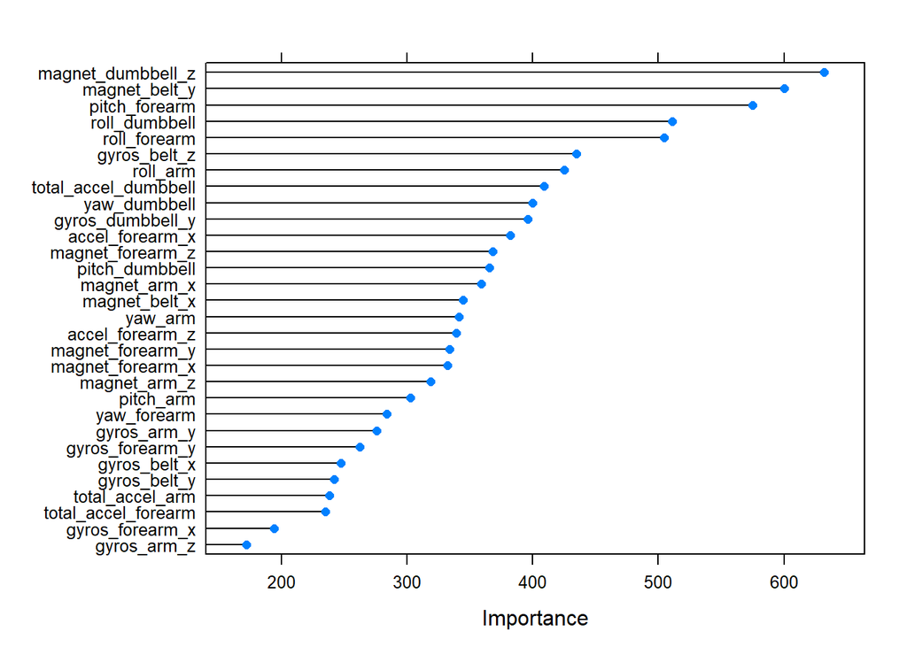

```r
plot(varImp(model_rf, scale = F))
```

## Test Set Predictions

Predictions on the test set were as follows:

```r
fin_test_preds <-
  preds[-cor_preds]

test_set <-
  test_data_sub[, ..fin_test_preds]

predict_test_rf <-
  predict(model_rf, test_set)

print(predict_test_rf)
```

```
##  [1] B A B A A E D B A A B C B A E E A B B B
## Levels: A B C D E
```